**=====================================================**

# Machine Failure Analysis

Noah MacGillivray | BIT-446 Assignment(T5) | Summer 2025

Model Evaluation of a KNN Classification Model

**Environment:** Ubuntu, VS Code

**=====================================================**

## Introduction

This program imports machine failure data for three different models with (possible) associated factors including hours run and average hours in-between maintenance. The data is prepared, splits for training and testing are made using both random stratified and stratified k-folds, and the k nearest neighbor (KNN) algorithm is applied to both. The results are then displayed for evaluation.

## Required packages

```r
# Load packages
library(readxl)
library(skimr)
library(dplyr)
library(class)
library(caTools)
library(caret)
```

```r
library(ggplot2)
library(lattice)
library(metrica)
cat("All packages loaded successfully!\n")
```

```
## All packages loaded successfully!
```

## Data Import and Initial Exploration

The machine failure data is read in using read_excel, head/tail/summary are printed to ensure proper import and view summary, and machine version prints what percentage of failures are in each group. The first 300 rows of dataset had no missing values for columns needed for KNN evaluation.

```r
failure_rate <- read_excel("BIT-446-RS-T4-T5-FailureRate.xlsx", n_max = 300)

# Print head
head(failure_rate)
```

```
## # A tibble: 6 × 5
##   record hours_run avg_hours_between_maint model_version failure
##    <dbl>     <dbl>                   <dbl>         <dbl>   <dbl>
## 1      1      1005                     382             3       0
## 2      2      1023                     380             1       0
## 3      3      1057                     319             1       0
## 4      4      1063                     566             3       0
## 5      5      1150                     767             1       0
## 6      6      1183                     230             1       0
```

```r
# Print tail
tail(failure_rate)
```

```
## # A tibble: 6 × 5
##   record hours_run avg_hours_between_maint model_version failure
##    <dbl>     <dbl>                   <dbl>         <dbl>   <dbl>
## 1    295      9796                    1659             1       0
## 2    296      9808                    1925             2       0
## 3    297      9823                    1887             2       0
## 4    298      9870                    1510             2       0
## 5    299      9978                    1782             3       0
## 6    300      9985                    1402             2       0
```

```r
# Print skimr dataset summary
skim(failure_rate)
```

Data summary

| Name | failure_rate |
| --- | --- |
| Number of rows | 300 |
| Number of columns | 5 |
| _______________________ |  |
| Column type frequency: |  |
| numeric | 5 |
| ________________________ |  |
| Group variables | None |

**Variable type: numeric**

| skim_variable | n_missing | complete_rate | mean | sd | p0 | p25 | p50 | p75 | p100 | hist |
| --- | --- | --- | --- | --- | --- | --- | --- | --- | --- | --- |
| record | 0 | 1 | 150.50 | 86.75 | 1 | 75.75 | 150.5 | 225.25 | 300 | ▇▇▇▇▇ |
| hours_run | 0 | 1 | 5420.08 | 2614.27 | 1005 | 3087.75 | 5397.5 | 7814.75 | 9985 | ▇▇▇▇▇ |
| avg_hours_between_maint | 0 | 1 | 1410.50 | 393.52 | 230 | 1148.75 | 1441.5 | 1755.00 | 1998 | ▁▁▆▇▇ |
| model_version | 0 | 1 | 2.00 | 0.82 | 1 | 1.00 | 2.0 | 3.00 | 3 | ▇▁▇▁▇ |
| failure | 0 | 1 | 0.21 | 0.41 | 0 | 0.00 | 0.0 | 0.00 | 1 | ▇▁▁▁▂ |

```r
# Machine number failure rate summary
model_version_summary <- failure_rate %>%
  group_by(model_version) %>%
  summarise(
    total_units = n(),
    failure_rate = mean(failure),
    .groups = "drop"
  )
cat("Machine Model Failure Distribution and Failure Rate")
```

```
## Machine Model Failure Distribution and Failure Rate
```

```r
# Prints the summary
print(model_version_summary)
```

```
## # A tibble: 3 × 3
##   model_version total_units failure_rate
##           <dbl>       <int>        <dbl>
## 1             1         100        0.19
## 2             2          99        0.202
## 3             3         101        0.228
```

## General impressions from summary

- 300 column vectors with 5 dimension.
- hours_run: uniform distribution with moderate standard deviation
- avg_hours_between_maint: left-skewed with moderate standard deviation
- failure: right skewed with high standard deviation
- Model data is equally distributed; model 3 has slightly higher failure rate

## Data Preparation

Do to the large range of values, hours_run and avg_hours_between_maint were normalized (z-score). The failure column is also converted to a factor to be used in the KNN models.

```r
# Normalize only the features of interest; default is z-score
failure_rate$hours_run <- as.vector(scale(failure_rate$hours_run))

failure_rate$avg_hours_between_maint <-
  as.vector(scale(failure_rate$avg_hours_between_maint))

# Failure column converted to a factor
failure_rate$failure <- as.factor(failure_rate$failure)
```

## Data splitting for *Stratified* KNN training

```r
# Set seed for reproducible results
set.seed(44)

# Stratified random split 70/30
sample <- sample.split(failure_rate$failure, SplitRatio = 0.7)

# Distribute the split data to training and testing
train_failure <- subset(failure_rate, sample == TRUE)
test_failure <- subset(failure_rate, sample == FALSE)
```

## Apply KNN (*Stratified*)

This bock applies the KNN algorithm based on hours_run and avg_hours_between_maint features and failure target. A k-value of 5 was selected based on our last analysis using KNIME. The function returns an object of failure criteria to be compared to the known failures of the associated column vector.

```r
# Apply KNN classification with hours_run and avg_hours_between_maint
failure_knn <- knn(
  train_failure[c("hours_run", "avg_hours_between_maint")],
  test_failure[c("hours_run", "avg_hours_between_maint")],
  cl = train_failure$failure, # Class labels
  k = 5
)
```

## Data splitting for *k-folds* KNN training

The data splitting for k-folds is a bit different than using a stratified approach. It still uses a seed for reproducibility and a stratified approach when placing data into each fold, but builds 10 separate folds (tests) to apply the KNN model. This block also creates a column vector of specified k-values to be tested along with the dataset below.

```r
# Set seed for reproducibility
set.seed(44)

# Set up 10 fold cross validation via caret package
ctrl <- trainControl(
  method = "cv",           # Cross validation
  number = 10,             # 10 folds
  savePredictions = "final" # Save predictions for confusion matrix
)

# Define k values to test
k_grid <- data.frame(k = c(3, 5, 7, 9, 11, 13, 15, 17))
```

## Apply KNN (*k-folds*)

This block uses the caret library and is where the k_NN model is applied to the 10 separate folds and each of the k-values in the vector above. It averages the outcome accuracy and other metrics of the 10 different folds. This allows you to test and verify more of your data, prevent overfitting and hopefully provide better results on future data.

```r
# Apply KNN with k-fold cross-validation
knn_kfolds_model <- train(
  ## Predict failure based on hours_run + avg_hours_between_maint
  failure ~ hours_run + avg_hours_between_maint,
  # Data set we are using (from above)
  data = failure_rate,
  # KNN algorithm applied
  method = "knn",
  # Number of folds and cross validation we set above
  trControl = ctrl,
  # Test for each of the specified k-values above
  tuneGrid = k_grid,
  # Optimize for accuracy predicting failure
  metric = "Accuracy"
)
```

## Model Evaluation Metrics (*stratified*)

The following block binds the applied KNN model above with our test_failure column to provide a comparison on how well the KNN model performed. Displays include: confusion matrix, comprehensive metrics summary, and a scatter plot of the predictions.

```r
# Bind the KNN model with our data frame
test_obs_pred <- data.frame(test_failure, failure_knn)

# Display confusion matrix
confusionMatrix(test_obs_pred$failure_knn,
                test_obs_pred$failure,
                mode = "prec_recall")
```

```
## Confusion Matrix and Statistics
##
##           Reference
## Prediction  0  1
##          0 69  4
##          1  2 15
##
##                Accuracy : 0.9333
##                  95% CI : (0.8605, 0.9751)
##     No Information Rate : 0.7889
##     P-Value [Acc > NIR] : 0.0001641
##
##                   Kappa : 0.7918
##
##  Mcnemar's Test P-Value : 0.6830914
##
##               Precision : 0.9452
##                  Recall : 0.9718
##                      F1 : 0.9583
##              Prevalence : 0.7889
##          Detection Rate : 0.7667
##    Detection Prevalence : 0.8111
##       Balanced Accuracy : 0.8807
##
##        'Positive' Class : 0
##
```

```r
# Converts factors back to numerical values and
# places them in a df to use w/ metric summary
obs <- as.numeric(paste(test_failure$failure))
pred <- as.numeric(paste(test_obs_pred$failure_knn))
data <- data.frame(cbind(obs, pred))

# Create comprehensive metrics summary using metrica package
metrics_summary(
  data = data,
  obs = obs,
  pred = pred,
  pos_level = 1,
  type = "classification"
)
```

```
##         Metric        Score
## 1     accuracy   0.93333333
## 2   error_rate   0.06666667
## 3    precision   0.94520548
## 4       recall   0.97183099
## 5  specificity   0.78947368
## 6       balacc   0.88065234
## 7       fscore   0.95833333
## 8          agf   0.91273866
## 9        gmean   0.87591951
## 10        khat   0.79182729
## 11         mcc   0.79374057
## 12         fmi   0.95842578
## 13         bmi   0.76130467
## 14         csi   0.78409091
## 15      deltap   0.82755842
## 16       posLr   4.61619718
## 17       negLr   0.03568075
## 18         dor 129.37500000
## 19         npv   0.88235294
## 20         FPR   0.21052632
## 21         FNR   0.02816901
## 22         FDR   0.05479452
## 23         FOR   0.11764706
## 24      preval   0.78888889
## 25    preval_t   0.47404642
## 26     AUC_roc   0.42261905
## 27          p4   0.89147287
```

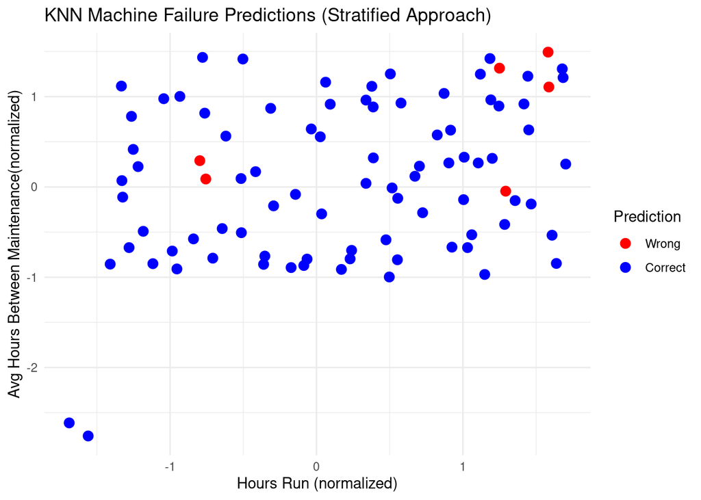

```r
# Scatter plot
ggplot(test_obs_pred, aes(x = hours_run, y = avg_hours_between_maint,
                          color = failure == failure_knn)) +
  geom_point(size = 3) +
  scale_color_manual(values = c("FALSE" = "red", "TRUE" = "blue"),
                     name = "Prediction", labels = c("Wrong", "Correct")) +
  labs(title = "KNN Machine Failure Predictions (Stratified Approach)",
       x = "Hours Run (normalized)",
       y = "Avg Hours Between Maintenance(normalized)") +
  theme_minimal()
```

## Model Evaluation Metrics (*k-folds*)

The following block prints and plots the k-value metrics from KNN model to provide a comparison on how well different k-values performed. It also displays the best k-value using the caret library. Other displays include: confusion matrix, comprehensive metrics summary, and a scatter plot of the predictions.

```r
# View results
print(knn_kfolds_model)
```

```
## k-Nearest Neighbors
##
## 300 samples
##   2 predictor
##   2 classes: '0', '1'
##
## No pre-processing
## Resampling: Cross-Validated (10 fold)
## Summary of sample sizes: 269, 270, 270, 271, 270, 270, ...
## Resampling results across tuning parameters:
##
##   k   Accuracy   Kappa
##    3  0.9533111  0.8569129
##    5  0.9534260  0.8572867
##    7  0.9599852  0.8743546
##    9  0.9667668  0.8926905
##   11  0.9701001  0.9024127
##   13  0.9701001  0.9024127
##   15  0.9667668  0.8926905
##   17  0.9667668  0.8926905
##
## Accuracy was used to select the optimal model using the largest value.
## The final value used for the model was k = 13.
```

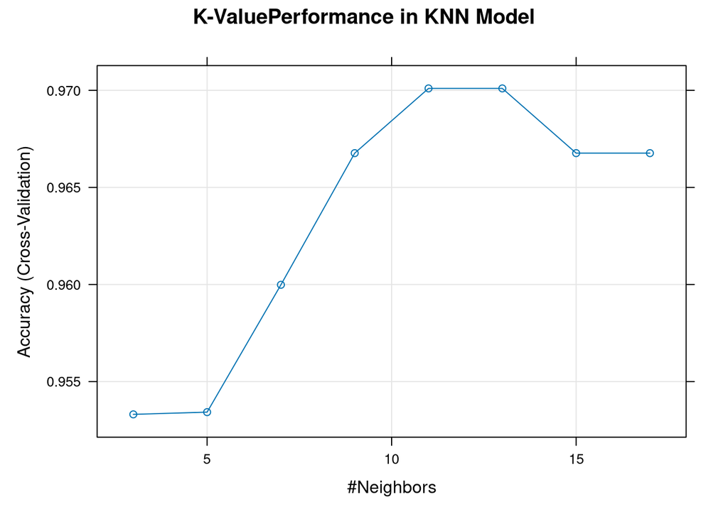

```r
# Plot k value performance
plot(knn_kfolds_model, main = "K-ValuePerformance in KNN Model")
```

```r
# Get the best k value
cat("Best k value:", knn_kfolds_model$bestTune$k, "\n")
```

```
## Best k value: 13
```

```r
# Confusion matrix for best model compiles across all folds
caret_cm <- confusionMatrix(knn_kfolds_model$pred$pred,
                            knn_kfolds_model$pred$obs, mode = "prec_recall")
print(caret_cm)
```

```
## Confusion Matrix and Statistics
##
##           Reference
## Prediction   0   1
##          0 236   7
##          1   2  55
##
##                Accuracy : 0.97
##                  95% CI : (0.9438, 0.9862)
##     No Information Rate : 0.7933
##     P-Value [Acc > NIR] : <2e-16
##
##                   Kappa : 0.9057
##
##  Mcnemar's Test P-Value : 0.1824
##
##               Precision : 0.9712
##                  Recall : 0.9916
##                      F1 : 0.9813
##              Prevalence : 0.7933
##          Detection Rate : 0.7867
##    Detection Prevalence : 0.8100
##       Balanced Accuracy : 0.9393
##
##        'Positive' Class : 0
##
```

```r
# Comprehensive metrics using metrica package
obs_caret <- as.numeric(paste(knn_kfolds_model$pred$obs))
pred_caret <- as.numeric(paste(knn_kfolds_model$pred$pred))
caret_data <- data.frame(cbind(obs = obs_caret, pred = pred_caret))

metrics_summary(
  data = caret_data,
  obs = obs_caret,
  pred = pred_caret,
  pos_level = 1,
  type = "classification"
)
```

```
##         Metric        Score
## 1     accuracy 9.700000e-01
## 2   error_rate 3.000000e-02
## 3    precision 9.711934e-01
## 4       recall 9.915966e-01
## 5  specificity 8.870968e-01
## 6       balacc 9.393467e-01
## 7       fscore 9.812890e-01
## 8          agf 9.676636e-01
## 9        gmean 9.378924e-01
## 10        khat 9.056999e-01
## 11         mcc 9.069454e-01
## 12         fmi 9.813420e-01
## 13         bmi 8.786934e-01
## 14         csi 7.919463e-01
## 15      deltap 9.361057e-01
## 16       posLr 8.782713e+00
## 17       negLr 9.472880e-03
## 18         dor 9.271429e+02
## 19         npv 9.649123e-01
## 20         FPR 1.129032e-01
## 21         FNR 8.403361e-03
## 22         FDR 2.880658e-02
## 23         FOR 3.508772e-02
## 24      preval 7.933333e-01
## 25    preval_t 4.860833e-01
## 26     AUC_roc 4.833906e-01
## 27          p4 9.519793e-01
```

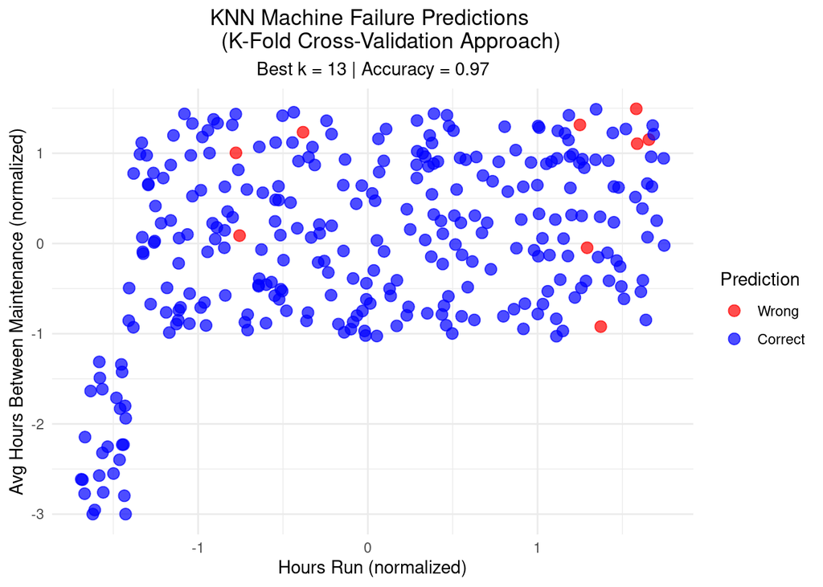

```r
pred_indices <- knn_kfolds_model$pred$rowIndex

# Create data frame for plotting
kfold_plot_data <- data.frame(
  hours_run = failure_rate$hours_run[pred_indices],
  avg_hours_between_maint = failure_rate$avg_hours_between_maint[pred_indices],
  actual = knn_kfolds_model$pred$obs,
  predicted = knn_kfolds_model$pred$pred,
  correct = knn_kfolds_model$pred$obs == knn_kfolds_model$pred$pred
)

# Scatter plot
ggplot(kfold_plot_data,
       aes(x = hours_run, y = avg_hours_between_maint, color = correct)) +
  geom_point(size = 3, alpha = 0.7) +
  scale_color_manual(values = c("FALSE" = "red", "TRUE" = "blue"),
                     name = "Prediction", labels = c("Wrong", "Correct")) +
  labs(title = "KNN Machine Failure Predictions
      (K-Fold Cross-Validation Approach)",
       subtitle = paste("Best k =", knn_kfolds_model$bestTune$k, "| Accuracy =",
                        round(max(knn_kfolds_model$results$Accuracy), 3)),
       x = "Hours Run (normalized)",
       y = "Avg Hours Between Maintenance (normalized)") +
  theme_minimal() +
  theme(plot.title = element_text(hjust = 0.5),
        plot.subtitle = element_text(hjust = 0.5))
```

## Conclusion and analysis

*After analysis of the KNN model of machine failure, yes it should be used to predict machine failure, and specifically, we should use the k-folds method with a k-value of 13.*

As we can see, a k-value of 13 gave us the best accuracy and Kappa scores. Although k=11 appeared to have the same values, it appears (after looking into it) either the caret library either chose 13 because of rounding that we did not see in the metrics,  
or other metrics it compared. The k-folds method not only produces a different/better k-value, but it also outperformed the stratified approach on ever other metric we investigated.

Of these metrics, the false omission rate may be the most important depending on what the machine is used for. If the machine is safety sensitive and may cause great harm to health, another safety measure may need to be set in place to catch as many of the 3% as possible.

**Further discussion** I wanted to run more tests (did not have time) isolating the hours run and maintenance intervals to see if one of those factors significantly showed a stronger corelation of machine failure. There is an obvious correlation of hours run and typical maintenance, but it would be interesting to see if one of those has more weight, or if there is a threshold of hours run to take that machine out of service.